# matplotlib

#### Inroducción a Matplotlib

¿Qué es Matplotlib?

- Matplotlib es una de las bibliotecas más utilizadas en Python para la visualización de datos.
- Es altamente flexible y permite crear una amplia variedad de gráficos, desde simples líneas hasta visualizaciones en 3D.
- Se inspiras en MATLAB y proporciona una API similar.
- Es compatible con otras bibliotecas como NumPy, Pandas y Seaborn.
- Permite la personalización avanzada de gráficos.

#### Instalación y configuración.

- Si aún no tienes Matplotlib instalado, puedes instalarlo con el siguiente comando en la terminal o en una celda de Jupyter Notebook.
- pip install matplotlib --> Terminal
- %pip install matplotlib --> Celda de Jupyter Notebook.
- pip install --upgrade matplotlib --> Si ya esta instalado y hay que actualizarlo.

```python
%pip install matplotlib
```

#### Importación de Matplotlib y su estructura básica.

- Para comenzar a utilizar Matplotlib, lo primero es importar la biblioteca.
- Generalmente, se usa la siguiente convención.

```python
import matplotlib.pyplot as plt
```

#### Creando un gráficio básico.

- Vamos a crear un gráfico de líneas sencillo.

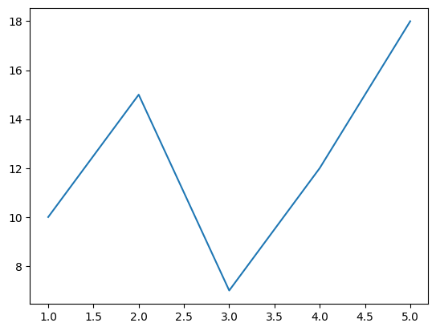

```python
x = [1, 2, 3, 4, 5]
y = [10, 15, 7, 12, 18]

# Crear el gráfico
plt.plot(x, y)
# Mostrar el gráfico.
plt.show()
```

#### Componentes básicos de una visualización en Matplotlib

1. Figure (fig): Es el contenedor principal del gráfico.
2. Axes (ax): Representa los ejes entro de la figura, donde se dibujan los gráficos.
3. Axis (x,y): Define los ejes individuales dentro de los Axes.
4. Labels: Son las etiquetas de los ejes y el título del gráfico.
5. Legend: Muestra la información de cada serie de datos.
6. Grid: Permite agregar líneas de referencia en el fondo.

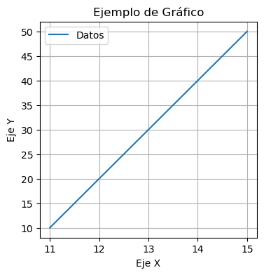

```python
x = [11, 12, 13, 14, 15]
y = [10, 20, 30, 40, 50]

plt.figure(figsize=(4,4))
plt.plot(x, y, label="Datos")
plt.xlabel("Eje X")
plt.ylabel("Eje Y")
plt.title("Ejemplo de Gráfico")
plt.legend()
plt.grid(True)
plt.show()
```

Vamos a crear un gráfico y le vamos a cambiar el tipo y el color de linea

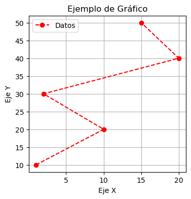

```python
x = [1, 10, 2, 20, 15]
y = [10, 20, 30, 40, 50]

plt.figure(figsize=(4,4))
plt.plot(x, y, label="Datos", color="red", linestyle="--", marker="o")
plt.xlabel("Eje X")
plt.ylabel("Eje Y")
plt.title("Ejemplo de Gráfico")
plt.legend()
plt.grid(True)
plt.show()
```

Gráfico de linea con multiples series de datos.

- Podemos representar varias líneas en un mismo gráfico.

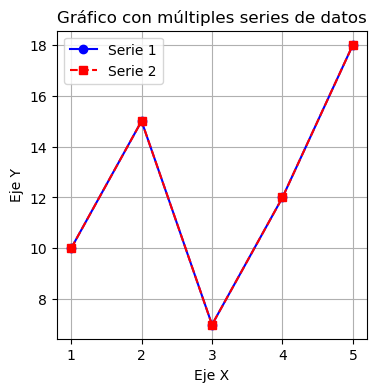

```python
x = [1,2,3,4,5]
y1 = [10,15,7,12,18]
y2 = [5,8,10,6,12]
plt.figure(figsize=(4,4))
plt.plot(x, y1, label='Serie 1', color='blue', linestyle='-', marker='o')
plt.plot(x, y1, label='Serie 2', color='red', linestyle='--', marker='s')

plt.xlabel("Eje X")
plt.ylabel("Eje Y")
plt.title("Gráfico con múltiples series de datos")
plt.legend()
plt.grid(True)
plt.show()
```

Personalización de un gráfico de lineas.

- Matplotlib permite personalizar completamente los gráficos con colores, estilos y más.

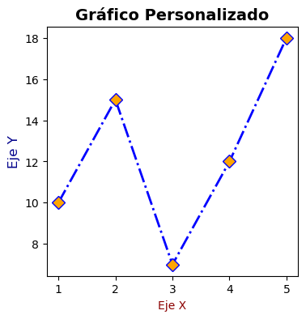

```python
x = [1,2,3,4,5]
y = [10,15,7,12,18]
plt.figure(figsize=(4,4))
plt.plot(x, y, color='blue', linewidth=2, linestyle='-.', marker='D', markersize=8, markerfacecolor='orange')
plt.xlabel("Eje X", fontsize=10, color='darkred')
plt.ylabel("Eje Y", fontsize=12, color='darkblue')
plt.title("Gráfico Personalizado", fontsize=14, fontweight='bold')
plt.show()
```

Gráfico con diferentes estilos predefinidos.

- Matplotlib tiene varios estilos predefinidos que pueden cambiar el aspecto de los gráficos fácilmente.
- Los estilos disponibles se pueden ver con: print(plt.style.aviable)

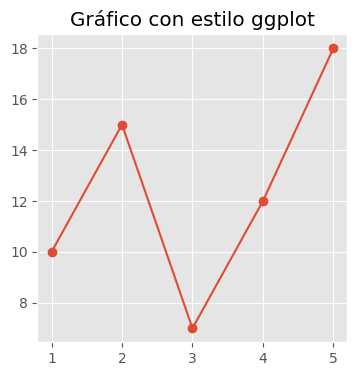

```python
plt.style.use("ggplot")

x = [1,2,3,4,5]
y = [10,15,7,12,18]
plt.figure(figsize=(4,4))
plt.plot(x, y , marker='o', linestyle='-')
plt.title("Gráfico con estilo ggplot")
plt.show()
```

```python
print(plt.style.available)
```

[output not shown]

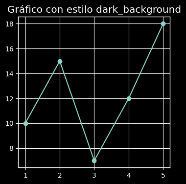

```python
plt.style.use("dark_background")

x = [1,2,3,4,5]
y = [10,15,7,12,18]
plt.figure(figsize=(4,4))
plt.plot(x, y , marker='o', linestyle='-')
plt.title("Gráfico con estilo dark_background")
plt.show()
```

```python
plt.style.use("classic")
```

Gráfico de dispersión simple (scatter)

- A diferencia de plot(),el gráfico de dispersión scatter() se usa para representar puntos individuales.

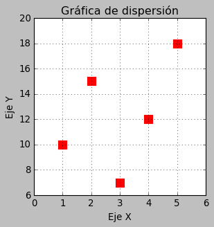

```python
x = [1,2,3,4,5]
y = [10,15,7,12,18]
plt.figure(figsize=(4,4))
plt.scatter(x, y , color='red', marker='s', s=100)
plt.xlabel("Eje X")
plt.ylabel("Eje Y")
plt.title("Gráfica de dispersión")
plt.grid(True)
plt.show()
```

Gráfico de barras básico.

- Los gráficos de barras bar() se usan para representar categorías.

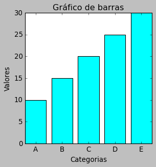

```python
categorias = ['A', 'B', 'C', 'D', 'E']
valores = [10, 15, 20, 25, 30]
plt.figure(figsize=(4,4))
plt.bar(categorias, valores, color='cyan')
plt.xlabel('Categorias')
plt.ylabel('Valores')
plt.title('Gráfico de barras')
plt.show()
```

Asi como podemos tener estilos de la gráfica personalizada, también tenemos instrucciones para acceder a mas elementos.

Referencias para marker

| Nombre | Descripcion | Nombre | Descripcion |
| --- | --- | --- | --- |
| 'o' | Circle | 'H' | Hexagon |
| '*' | Star | 'v' | Triangle Down |
| '.' | Poit | '^' | Triangle Up |
| ',' | Pixel | '<' | Triangle Left |
| 'x' | X | '>' | Triangle Right |
| '+' | Plus | '1' | Tri Down |
| 'X' | X(field) | '2' | Tri UP |
| 'P' | Plus (field) | '3' | Tri Left |
| 's' | Square | '4' | Tri Right |
| 'D' | Diamond | 'I' | Vline |
| 'p' | Pentagon | '_' | Hline |

Referencias tipo de Lineas

| Line Syntax | Descripción |
| --- | --- |
| '-' | Solid Line |
| ':' | Dotted Line |
| '--' | Dashed line |
| '-.' | Dashed/dotted line |

Referencia de Colores

| Color Syntax | Descripción |
| --- | --- |
| 'r' | Red |
| 'g' | Green |
| 'b' | Blue |
| 'c' | Cyan |
| 'm' | Magenta |
| 'y' | Yellow |
| 'k' | Black |
| 'w' | White |

#### Tipos de gráficos comunes en Matplotlib

- Matplotlib permite crear una gran variedad de gráficos, cada uno adecuado para diferentes tipos de visualización de datos.
- En esta sección, exploraremos algunos de los gráficos más comunes y cómo se crean.

Gráfico de lineas (Line Plot)

- Los gráficos de lineas son ideales para mostrar tendencias a lo largo del tiempo o para visualizar relaciones continuas entre dos variables.

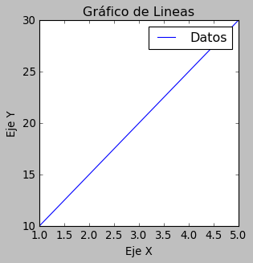

```python
x = [1,2,3,4,5]
y = [10,15,20,25,30]
plt.figure(figsize=(4,4))
plt.plot(x, y , label='Datos')
plt.xlabel('Eje X')
plt.ylabel('Eje Y')
plt.title('Gráfico de Lineas')
plt.legend()
plt.show()
```

Gráfico de barras (Bar Chart)

- El gráfico de barras es útil para mostrar comparaciones entre diferentes categorías.
- Cada barra representa un valor para una categoría dada.

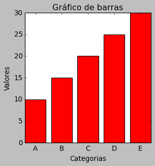

```python
categorias = ['A', 'B', 'C', 'D', 'E']
valores = [10, 15, 20, 25, 30]
plt.figure(figsize=(4,4))
plt.bar(categorias, valores, color='red')
plt.xlabel('Categorias')
plt.ylabel('Valores')
plt.title('Gráfico de barras')
plt.show()
```

Gráfico de dispersión (Scatter Plot)

- El gráfico de dispersión es ideal para mostrar la relación entre dos variables numéricas.
- Cada punto representa una observación.

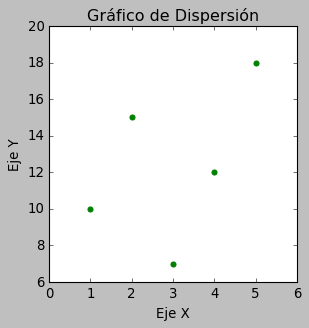

```python
x = [1, 2, 3, 4, 5]
y = [10, 15, 7, 12, 18]
plt.figure(figsize=(4,4))
plt.scatter(x, y, color='green')
plt.xlabel("Eje X")
plt.ylabel("Eje Y")
plt.title("Gráfico de Dispersión")
plt.show()
```

Histograma (Histogram)

- Los histogramas son útiles para mostrar la distribución de una variable numérica.
- Muestran la frecuencia con la que ocurren los valores dentro de los rangos.

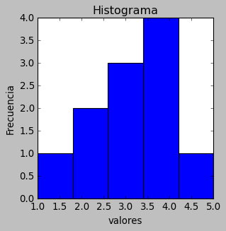

```python
datos = [1,2,2,3,3,3,4,4,4,4,5]
plt.figure(figsize=(4,4))
plt.hist(datos, bins=5, color='blue', edgecolor='black')
plt.xlabel("valores")
plt.ylabel('Frecuencia')
plt.title('Histograma')
plt.show()
```

Gráfico de pastel (Pie Chart)

- El gráfico de pastel se utiliza para mostrar la proporción de cada categoría en relación con el total.

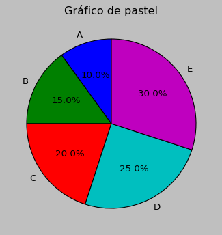

```python
categorias = ['A', 'B', 'C', 'D', 'E']
valores = [10, 15, 20, 25, 30]

plt.figure(figsize=(5,5))
plt.pie(valores, labels=categorias, autopct='%1.1f%%', startangle=90)
plt.title('Gráfico de pastel')
plt.show()
```

#### Personalización de Gráficos en Python

- Matplotlib permite una gran cantidad de personalización para adoptar los gráficos a sus necesidades, desde cambiar colores hasta modificar las leyendas y etiquetas.

Cambio de color.

- Se puede cambiar el color de las líneas, barras, puntos, entre otros.
- Los colores se pueden definir por nombre, por código hexadecimal o usando mapas de colores.

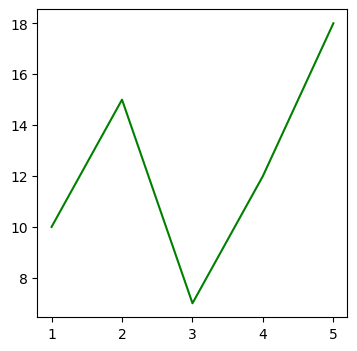

```python
import matplotlib.pyplot as plt

# Datos
x = [1, 2, 3, 4, 5]
y = [10, 15, 7, 12, 18]

plt.figure(figsize=(4,4))
# Cambiar color de la línea
plt.plot(x, y, color='green')  # También puedes usar códigos hexadecimales como '#FF5733'

plt.show()
```

Estilo de línea y color.

- Se puede cambiar el estilos de la línea (sólida, discontinua, punteada, etc) y el grosor de la línea.

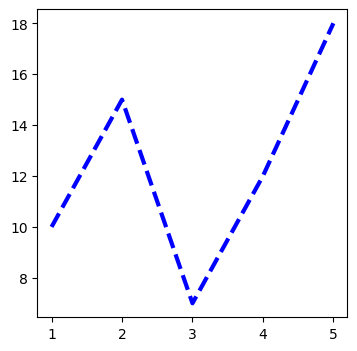

```python
x = [1, 2, 3, 4, 5]
y = [10, 15, 7, 12, 18]

plt.figure(figsize=(4,4))
# Estilo de línea y grosor
plt.plot(x, y, linestyle='--', linewidth=3, color='blue')  # Línea discontinua y grosor 3

plt.show()
```

Etiquetas y Títulos.

- Se pueden agregar títulos, etiquetas a los ejes y leyendas para hacer que los gráficos sean más informativos.

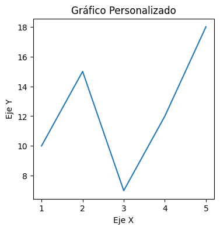

```python
x = [1, 2, 3, 4, 5]
y = [10, 15, 7, 12, 18]

plt.figure(figsize=(4,4))
plt.plot(x, y)
plt.title("Gráfico Personalizado")
plt.xlabel("Eje X")
plt.ylabel("Eje Y")
plt.show()
```

Leyendas.

- Las leyendas son útiles cuando se tienen múltiples series de datos en un gráfico.
- Se puede usar el parámetro label en cada serie y luego mostrar la leyenda con plt.legend()

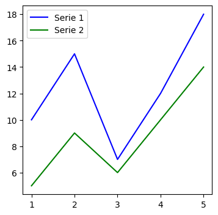

```python
x = [1, 2, 3, 4, 5]
y1 = [10, 15, 7, 12, 18]
y2 = [5, 9, 6, 10, 14]

plt.figure(figsize=(4,4))
plt.plot(x, y1, label="Serie 1", color='blue')
plt.plot(x, y2, label="Serie 2", color='green')
plt.legend()
plt.show()
```

Sub-gráficos (Subplots)

- Cuando quieras crear varios gráficos en una sola figura, puedes usar plt.subplots().
- Esto nos permite crear sub-gráficos y personalizarlos individualmente.

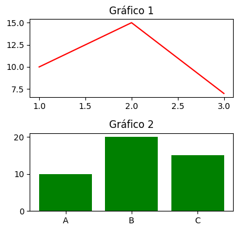

```python
# Crear subgráficos: 2 filas, 1 columna
fig, axs = plt.subplots(2, 1, figsize=(4, 4))

# Gráfico 1 (arriba)
axs[0].plot([1, 2, 3], [10, 15, 7], color='red')
axs[0].set_title("Gráfico 1")

# Gráfico 2 (abajo)
axs[1].bar(['A', 'B', 'C'], [10, 20, 15], color='green')
axs[1].set_title("Gráfico 2")

# Mostrar los subgráficos
plt.tight_layout()
plt.show()
```

Configuración de los Ejes.

- Se pueden personalizar los ejes de los gráficos, como establecer los límites de los ejes, cambiar los ticks, y rotar las etiquetas.

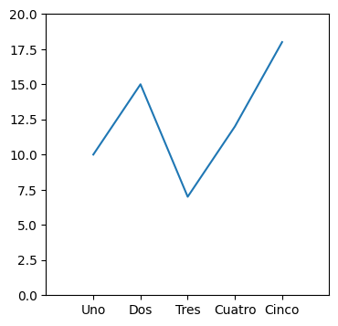

```python
x = [1, 2, 3, 4, 5]
y = [10, 15, 7, 12, 18]


plt.figure(figsize=(4,4))
# Crear gráfico
plt.plot(x, y)
# Cambiar límites de los ejes
plt.xlim(0, 6)  # Límite para el eje X
plt.ylim(0, 20)  # Límite para el eje Y
# Cambiar los ticks
plt.xticks([1, 2, 3, 4, 5], ['Uno', 'Dos', 'Tres', 'Cuatro', 'Cinco'])
# Mostrar gráfico
plt.show()
```

#### Estilos y temas en Matplotlib.

- Matplotlib permite cambiar el estilo de los gráficos para darles una apariencia más profesional o adaptarlos a diferentes necesidades.
- En esta sección, aprenderemos cómo aplicar estilos predefinidos y personalizar los gráficos aún mas.

Cambiar el estilo del Gráfico.

- Matplotlib proporciona varios estilos predefinidos que se pueden aplicar fácilmente usando plt.style.use().
- Esos estilos cambian automáticamente los colores, fuentes, líneas y otros elementos del gráfico.

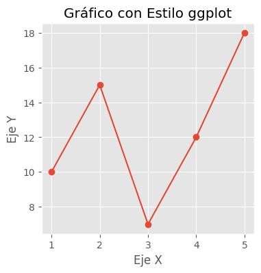

```python
# Aplicar un estilo
plt.style.use('ggplot')  # Cambia el diseño del gráfico

x = [1, 2, 3, 4, 5]
y = [10, 15, 7, 12, 18]


plt.figure(figsize=(4,4))
plt.plot(x, y, marker='o')
plt.xlabel("Eje X")
plt.ylabel("Eje Y")
plt.title("Gráfico con Estilo ggplot")

plt.show()
```

Personalización de colores con Mapas de colores (Colormap)

- Matplotlib incluye una serie de mapas de colores (colormaps) que se pueden usar para aplicar degradados o paletas de colores a los gráficos.

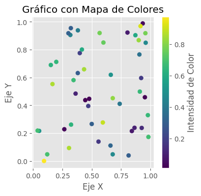

```python
import matplotlib.pyplot as plt
import numpy as np

x = np.random.rand(50)
y = np.random.rand(50)
colores = np.random.rand(50)  # Asignar colores aleatorios


plt.figure(figsize=(4,4))
# Crear gráfico de dispersión con un colormap
plt.scatter(x, y, c=colores, cmap='viridis')
# Agregar una barra de colores
plt.colorbar(label="Intensidad de Color")
plt.xlabel("Eje X")
plt.ylabel("Eje Y")
plt.title("Gráfico con Mapa de Colores")
plt.show()
```

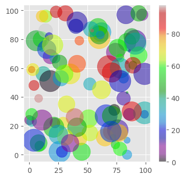

```python
import numpy as np

x = np.random.randint(100, size=(100))
y = np.random.randint(100, size=(100))
colors = np.random.randint(100, size=(100))
sizes = 10 * np.random.randint(100, size=(100))
plt.figure(figsize=(4,4))
plt.scatter(x, y, c=colors, s=sizes, alpha=0.5, cmap='nipy_spectral')
plt.colorbar()
plt.show()
```

Cambiar el tema de fondo.

- Si deseas modificar el color de fondo del gráfico, se puede usar plt.style.use('dark_backgroud') o modificar manualmente el fondo con ax.set_facecolor().

```python
plt.style.use("classic")
```

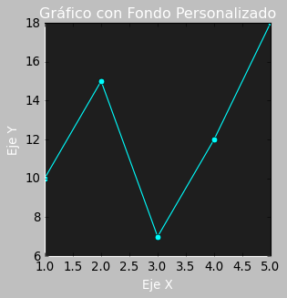

```python
# Crear figura y ejes
fig, ax = plt.subplots(figsize=(4,4))


#plt.figure(figsize=(4,4))
# Cambiar el color de fondo del gráfico
ax.set_facecolor('#1e1e1e')  # Color oscuro


# Datos
x = [1, 2, 3, 4, 5]
y = [10, 15, 7, 12, 18]

# Crear gráfico
ax.plot(x, y, color='cyan', marker='o')

# Etiquetas y título
ax.set_xlabel("Eje X", color='white')
ax.set_ylabel("Eje Y", color='white')
ax.set_title("Gráfico con Fondo Personalizado", color='white')

# Cambiar color de los ejes
ax.spines['bottom'].set_color('white')
ax.spines['left'].set_color('white')
ax.xaxis.label.set_color('white')
ax.yaxis.label.set_color('white')
plt.show()
```

Colormaps Disponibles

Su Reverse --> Accent_r (Asi para todos los colormaps disponibles)

| Nombre |  |  |  |  |  |  |  |  |
| --- | --- | --- | --- | --- | --- | --- | --- | --- |
| Accent | Oranges | RdBu | YlGn | cool | gist_yarg | plasma |  |  |
| Blues | PRGn | RdGy | YlGnBu | coolwarm | gnuplot | prism |  |  |
| BrBg | Paired | RdPu | YlOrBr | copper | gnuplot2 | rainbow |  |  |
| BuGn | Pastel1 | RdYlBu | YlOrRd | cubehelix | gray | seismic |  |  |
| BuPu | Pastel2 | RdYlGn | afmhot | flag | hot | spring |  |  |
| CMRmap | PiYG | Reds | autumn | gist_earth | hsv | tab10 |  |  |
| Dark2 | PuBu | Set1 | binary | gist_gray | inferno | magma |  |  |
| GnBu | PuBuGn | Set2 | bone | gist_heat | jet | tab20b |  |  |
| Greens | PuOr | Set3 | brg | gist_ncar | nipy_spectral | tab20c |  |  |
| Greys | PuRd | Spectral | bwr | gist_rainbow | ocean | terrain |  |  |
| OrRd | Purples | Wistia | cividis | gist_stern | pink | twilight |  |  |
| twilight_shifted | viridis | winter | tab20 | summer |  |  |  |  |